# The Fundamental Problem of Inferential Statistics

P. Lombardo

## Loading packages and data

```r
library(tidyverse)
population<-read.csv('data/pop_sim.csv',header = T)
```

# A Fundamental Problem

> In statistics, we almost never work with an entire population of data. Instead, we make **inferences** based on a randomly selected sample from the population. But there is a fundamental flaw with this approach: *Each random sample one could take from a population will give different information!*

We can demonstrate this by actually sampling from a population! We loaded a data frame called `population` which contains information from a fictional population of 100,000 people. We recorded each person’s **IQ** and whether or not they were born with at least one wisdom tooth **wisdom_teeth** (coded as *Yes* or *No*).

We can use the `sample()` function from `R` to take a random sample of measurements from this population. Let’s each take our own random sample, and we’ll compare what happens:

```r
# replace the number inside set.seed(...) with your birthday. For example May 12th
# is written as 512
set.seed(512)

# Now let's take a random sample from the IQ measurements using the sample() function.
# Save your sample as S1
S1 <- sample(population$IQ, 30)

# What is the mean IQ for your sample?
mean(S1)
```

```
## [1] 104.9
```

*Share your mean with the class!*

Now let’s use `sample()` to grab a random sample from the **wisdom_teeth** measurements. We’ll summarize it to give the percentage *without* wisdom teeth (i.e. the “No” response):

```r
# Take a random sample and save it as S2
S2 <- sample(population$wisdom_teeth, 30)
S2
```

```
##  [1] "Yes" "Yes" "Yes" "No"  "Yes" "Yes" "No"  "Yes" "Yes" "Yes" "Yes" "Yes"
## [13] "No"  "Yes" "Yes" "No"  "No"  "No"  "Yes" "Yes" "Yes" "Yes" "No"  "Yes"
## [25] "Yes" "No"  "Yes" "Yes" "Yes" "No"
```

```r
# Now find the percentage that said "No" in S2
S2 %>% table() %>% prop.table()
```

```
## .
##  No Yes
## 0.3 0.7
```

```r
sum(S2=="No")/30
```

```
## [1] 0.3
```

*Share your percentage with the class!*

#### What are the parameters?

Typically, we can’t say. However, for this exploration I give you all the population data in the `population` data frame. So we can actually sneak a peak at the real population parameters:

```r
mean(population$IQ)
```

```
## [1] 108.0316
```

```r
population$wisdom_teeth %>% table() %>% prop.table()
```

```
## .
##      No     Yes
## 0.35065 0.64935
```

**Notice how our sample mean and sample percentage guesses from above are close, but not equal to the population parameters. More importantly, there is a good amount of variation in our guesses as we shared our answers around the class today.**

> We use the term *Sampling Variation* (or sampling error) to refer to this natural variation in a statistic that arises from the random sampling process.

*Sampling variation is unavoidable in inferential statistcs.*

## Working with Sampling Variation

So if our guesses (the statistic we get from a random sample) are always wrong and subject to *sampling variation*, *what can we do?* How do we make “smart” inferences on such a flawed piece of information? Let’s learn from the best fictional inferentialist there is!

> “**While the individual man is an insoluble puzzle, in the aggregate he becomes a mathematical certainty.**” – Sherlock Holmes (Sir Arthur Conan Doyle, *The Sign of Four*).

In a similar way, individual statistics (or guesses based on a sample) are wild because of sampling variation. *However,* IN THE AGGREGATE they have quite predictable and useful behavior.

To explore this “aggregate behavior” of a statistic, we use a tool called a sampling distribution.

> A **sampling distribution for a statistic** can be considered a very large data set of statistics generated from a large collection of random samples from a population.

Here’s a recipe for creating a sampling distribution, which assumes we have access to an entire population of data. (We do not usually, but we’ll see how to circumvent this soon.)

1. Take a random sample from the population.
2. Summarize the information in that sample, and store it in a new data set.
3. Repeat this process about 10,000 - 100,000 times.

The data set of summaries we just generated is a *sampling distribution*.

Let’s make one together, and explore the aggregate behavior.

### Sampling Distribution for the Mean IQ

We will use a simple for loop to collect 10,000 sample mean IQ guesses from our fictional `population`. Let’s use a sample size of 30.

```r
# First we create a storage vector for our means:
sample_means<-numeric(10000)
# here is the general format for an R for-loop
for (i in 1:10000){
    # Place directions here.
    S1<- sample(population$IQ,100)
    # get sample mean
    samp_mean <- mean(S1)
    # now store it in the ith position of sample_means
    sample_means[i] <- samp_mean
}
```

```r
sample_means %>% head()
```

```
## [1] 108.08 106.46 108.47 108.39 109.04 107.64
```

Now create a summary table for the sampling distribution we created; remember we stored our sampling distribution data in `sample_means`. Compute the mean, median, and standard deviation.

```r
# place code here
# I start by creating a data frame so we can use tidyverse to do our
# summarizing.  Add to the code below
data.frame(x = sample_means) %>%
    summarize(
        mean = mean(x),
        median = median(x),
        std.dev = sd(x),
        IQR = IQR(x)
    )
```

```
##       mean median  std.dev  IQR
## 1 108.0275 108.02 1.018174 1.36
```

```r
mean(population$IQ)
```

```
## [1] 108.0316
```

1. *How does the mean compare against the actual population mean IQ?*

These are essentially the same, both about 108.

2. *Re-run the loop above, but change the sample size to 100. What happens to the standard deviation of the sampling distribution for mean IQ?*

As we increase sample size, the standard deviation of the sample mean guesses decreased (from about 1.8 with n = 30, to about 0.99 with n = 100).

- this reflects our sample mean guesses getting *better* because we are collecting more information (100 measurements versus 30).

Next create a histogram for our sampling distribution.

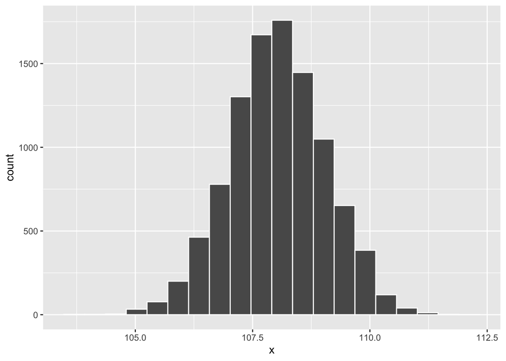

```r
# place code here
# As above, we will need to create a quick data.frame() to work with ggplot
# Add to the code below

ggplot(data = data.frame(x = sample_means),
       aes(x = x))+
    geom_histogram(color = 'white', bins = 20)
```

3. *What’s the “Shape” of this sampling distribution?*

The sampling distribution has a *normal shape*.

- Normal shapes are special because *THE EMPIRICAL RULE APPLIES!*

```r
data.frame(x = sample_means) %>%
    summarize(
        mean = mean(x),
        stdev = sd(x)
    )
```

```
##       mean    stdev
## 1 108.0275 1.018174
```

Our empirical region is:

```r
# mean +/ 2*stdev
108.0275 + c(-2,2)*1.00182
```

```
## [1] 106.0239 110.0311
```

- We can say that 95% of our sample means (coming from a random sample) will fall between 106.02 and 110.03.

```r
mean(sample(population$IQ,100))
```

```
## [1] 107.69
```

I know there is a 95% chance that this 107.69 is within 2 units of the actual population mean.

**Note:** Knowing this requires that I know the standard deviation of the sampling distribution.

### Sampling Distribution for the percentage without wisdom teeth

The aggregated behavior of sample percentages also follows the trends we saw above!

```r
population %>% head()
```

```
##    IQ wisdom_teeth
## 1 107           No
## 2  98          Yes
## 3  87           No
## 4 121          Yes
## 5  97           No
## 6 106          Yes
```

To summarize `wisdom_teeth` information, we need to use percentages. Here we use a sample percentage to guess the population percentage. But, as before, we should expect sampling variation in this sample percentage statistic.

To explore this, we create another sampling distribution.

We will use a simple for loop to collect 20,000 sample *percentage* guesses from our fictional `population`. Let’s use a sample size of 30.

```r
# First we create a storage vector for our means:
sample_percents<-numeric(20000)

# here is the general format for an R for-loop
for (i in 1:20000){
    # Place directions here.
    # get a random sample of wisdom teeth observations:
    S1 <- sample(population$wisdom_teeth, 100)

    sample_percents[i] <- sum(S1 == "No")/100

}
```

```r
sample_percents %>% head()
```

```
## [1] 0.36 0.33 0.44 0.34 0.36 0.35
```

Now create a summary table for the sampling distribution we created; remember we stored our sampling distribution data in `sample_percents`. Compute the mean, median, and standard deviation.

```r
# place code here
# As before, create a data.frame() first so we can use the dplyr pipes to summarise
data.frame(x = sample_percents) %>%
    summarize(
        mean = mean(x),
        median = median(x),
        stdev = sd(x)
    )
```

```
##        mean median      stdev
## 1 0.3506585   0.35 0.04732276
```

Population percentage that said “No”:

```r
table(population$wisdom_teeth=="No") %>% prop.table()
```

```
##
##   FALSE    TRUE
## 0.64935 0.35065
```

1. *How does the mean compare against the actual population that said “No”?*

They’re basically the same, about 35%.

2. *Re-run the loop above, but change the sample size to 100. What happens to the standard deviation of the sampling distribution for Sample Percentage of “No”*

We see the variation in the sample percentage guesses decrease as sample size increases (from about sd = 8% with n = 30, to about sd = 4.7% when n = 100.)

Next create a histogram for our sampling distribution.

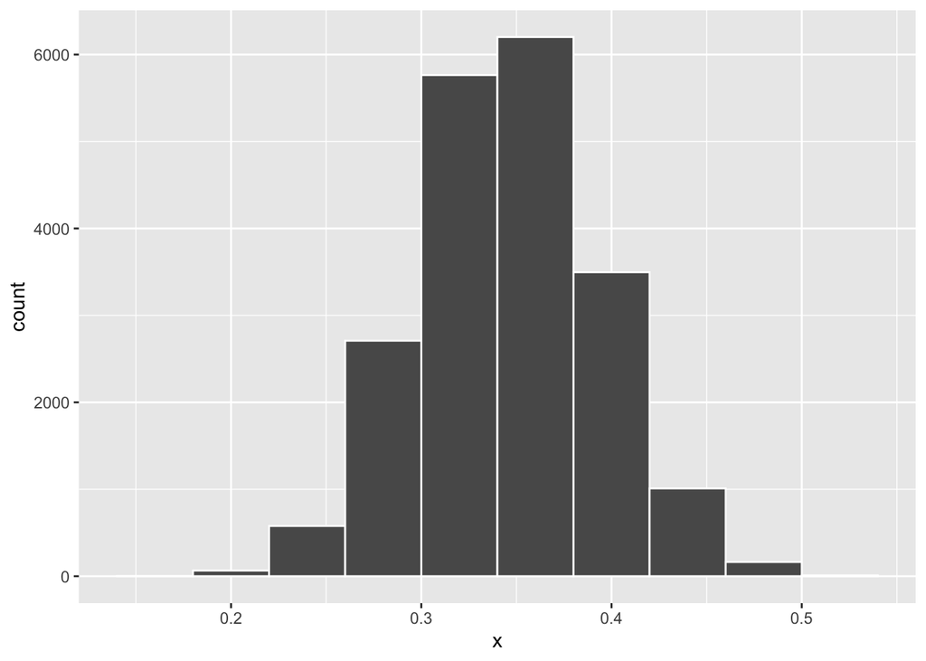

```r
# place code here
# Remember to create a data.frame() first so we can use ggplot
data.frame(x = sample_percents) %>%
    ggplot(data = .,
           aes(x = x))+
    geom_histogram(color='white', bins = 10)
```

3. *What’s the “Shape” of this sampling distribution?*

*Once again, the shape of the sampling distribution for sample percentages is NORMAL*.

- Empirical rule will apply, and we can get a sense of where 95% of the sample percentage guess will fall.

```r
# from sampling distribution
# mean +/- 2*stdev
0.350788 + c(-2,2)*0.04770024
```

```
## [1] 0.2553875 0.4461885
```

## Summarizing Sampling distributions

So what “aggregate behavior” can we expect from our statistics? Under certain assumptions, it turns out sampling distributions all share three important properties that provide the basis of our inferential statistics techniques:

1. The mean of the sampling distribution data *is the same (more or less) as* the actual population parameter.
2. As sample size increases, the variation in the sampling distribution (as measured by std deviation) *decreases*.
3. The shape of the sampling distribution is *normal* (so empirical rule will apply).

*Technical Note:* These properties we observe only work for certain statistics (specifically means and percentages), and only when our sample size is “large.” In fact, this behavior is the result of an important mathematical/statistical theorem called *The Central Limit Theorem*, which we will explore next.